# A Visual and Statistical Analysis of the Titanic Survivor Data

## Introduction

The following analysis of the Titanic Data aims to discover any correlation between certain demographics/location parameters and survival rates. The data covers 891 passengers with information related to their passenger class, name, gender, age, number of siblings and spouses, number of parents and children, ticket ID, fare price, cabin, and embarkment location. Using the data, the following questions can be posed:

Demographic based survival questions:

- Were women more likely to survive than men?
- Were children more likely to survive than adults?
- Were families more likely to survive than single adults?
- Were first class passengers more likely to survive than second or third?

Location based survival questions:

- Were passengers from a certain embarkment location more likely to survive?
- Were passengers from specific Cabin groups (A-G) more likely to survive?
- Were passengers with lower numerical Cabin locations more likely to survive?
- Were passengers with higher fares in each Cabin group more likely to survive?
- Were passengers with higher fares in each Passenger Class more likely to survive?

First the data file is imported using the Pandas csv module:

```python
#Keeping the document presentation clean from errors
import warnings
warnings.filterwarnings('ignore')

#Display module to show multiple outputs from a single input
from IPython.display import display, Markdown, Latex

#Importing the Pandas and OS modules to import, manipulate,
#and chart the CSV data file.
import pandas as pd
import os

#Importing the matplotlib module for charts and graphs
%matplotlib inline
import matplotlib.style as stl
import matplotlib.pyplot as plt
stl.use('seaborn-paper')
stl.use('seaborn-whitegrid')
plt.rcParams.update({'axes.titlesize':'xx-large'})
plt.rcParams.update({'axes.labelsize':'xx-large'})
plt.rcParams.update({'xtick.labelsize':'large'})
plt.rcParams.update({'ytick.labelsize':'large'})


#Importing functions from SciPy and NumPy functionality
#for array transformations
from scipy.stats import chi2_contingency,\
ttest_ind_from_stats, linregress
import numpy as np
```

```python
#Reading and Importing the file
titanicCsv = '/titanic_data.csv'
csvLocation = os.getcwd()+titanicCsv
data = pd.read_csv(csvLocation)
data.head()
```

|  | PassengerId | Survived | Pclass | Name | Sex | Age | SibSp | Parch | Ticket | Fare | Cabin | Embarked |
| --- | --- | --- | --- | --- | --- | --- | --- | --- | --- | --- | --- | --- |
| 0 | 1 | 0 | 3 | Braund, Mr. Owen Harris | male | 22.0 | 1 | 0 | A/5 21171 | 7.2500 | NaN | S |
| 1 | 2 | 1 | 1 | Cumings, Mrs. John Bradley (Florence Briggs Th... | female | 38.0 | 1 | 0 | PC 17599 | 71.2833 | C85 | C |
| 2 | 3 | 1 | 3 | Heikkinen, Miss. Laina | female | 26.0 | 0 | 0 | STON/O2. 3101282 | 7.9250 | NaN | S |
| 3 | 4 | 1 | 1 | Futrelle, Mrs. Jacques Heath (Lily May Peel) | female | 35.0 | 1 | 0 | 113803 | 53.1000 | C123 | S |
| 4 | 5 | 0 | 3 | Allen, Mr. William Henry | male | 35.0 | 0 | 0 | 373450 | 8.0500 | NaN | S |

## Descriptive statistics

Now that the data file has been imported, here are some basic statistics and percentages of the passengers:

```python
display(data.dtypes)
display(data.info())
display(data.describe())
```

```
PassengerId      int64
Survived         int64
Pclass           int64
Name            object
Sex             object
Age            float64
SibSp            int64
Parch            int64
Ticket          object
Fare           float64
Cabin           object
Embarked        object
dtype: object
```

```
<class 'pandas.core.frame.DataFrame'>
RangeIndex: 891 entries, 0 to 890
Data columns (total 12 columns):
PassengerId    891 non-null int64
Survived       891 non-null int64
Pclass         891 non-null int64
Name           891 non-null object
Sex            891 non-null object
Age            714 non-null float64
SibSp          891 non-null int64
Parch          891 non-null int64
Ticket         891 non-null object
Fare           891 non-null float64
Cabin          204 non-null object
Embarked       889 non-null object
dtypes: float64(2), int64(5), object(5)
memory usage: 83.6+ KB
```

```
None
```

|  | PassengerId | Survived | Pclass | Age | SibSp | Parch | Fare |
| --- | --- | --- | --- | --- | --- | --- | --- |
| count | 891.000000 | 891.000000 | 891.000000 | 714.000000 | 891.000000 | 891.000000 | 891.000000 |
| mean | 446.000000 | 0.383838 | 2.308642 | 29.699118 | 0.523008 | 0.381594 | 32.204208 |
| std | 257.353842 | 0.486592 | 0.836071 | 14.526497 | 1.102743 | 0.806057 | 49.693429 |
| min | 1.000000 | 0.000000 | 1.000000 | 0.420000 | 0.000000 | 0.000000 | 0.000000 |
| 25% | 223.500000 | 0.000000 | 2.000000 | NaN | 0.000000 | 0.000000 | 7.910400 |
| 50% | 446.000000 | 0.000000 | 3.000000 | NaN | 0.000000 | 0.000000 | 14.454200 |
| 75% | 668.500000 | 1.000000 | 3.000000 | NaN | 1.000000 | 0.000000 | 31.000000 |
| max | 891.000000 | 1.000000 | 3.000000 | 80.000000 | 8.000000 | 6.000000 | 512.329200 |

A few takeaways from this chart:

- 38% of the 891 passengers survived
- 50% or more of the passengers were 3rd class tickets
- 50% or more of passengers traveled alone, without children, parents, siblings, or spouses
- 50% of the tickets were cheaper than \$14.45 but with the mean ticket price of \$32.20 there were some extreme outliers that will skew this distribution
- The average age of the passengers was close to 30
  - The age distribution was not able to show using the describe function, this might pose an issue in the analysis if there is no workaround

## Data Wrangling

There will be 4 new columns created to make finding trends and correlations more manageable:

- AgeCat - passengers put into specific Age Categories. There will be better insight to compare passengers in different age groups while also giving the null values a category so that it takes away any issues when comparing data.
- SingFam - passengers will be put into two categories - single or family - depending on their values in SibSp or Parch. This will also make it easier to find correlation between survivors and non-survivors
- The Cabin values are difficult to process as is, so two new columns will be created:
  - CabLet - Passengers with Cabin values will be grouped by the first letter in their cabin location
  - CabNum - Cabins that have a single Cabin location will have their numerical value parsed

#### Age Categories - 'AgeCat'

AgeCat covers these broad age groups:

```
      infant:  0 < age <=  3
       child:  3 < age <= 10
       youth: 10 < age <= 16
 young adult: 16 < age <= 30
middle adult: 30 < age <= 45
 older adult: 45 < age <= 65
     elderly: 65 < age
   undefined: NaN
```

The new AgeCat column is inserted into the dataframe below:

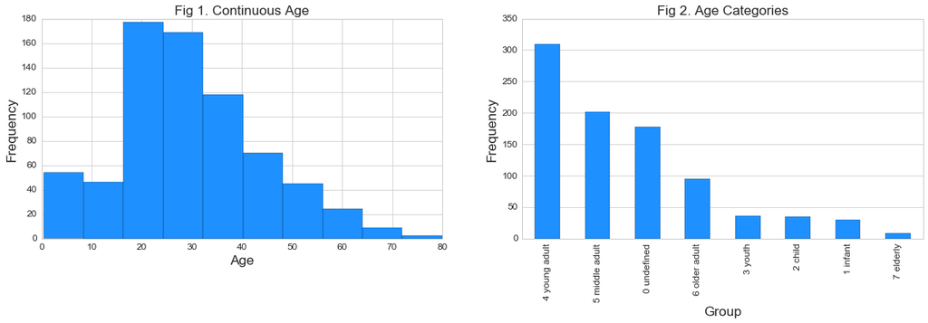

```python
#The numerical values are placed in front of the categories
#for graphing purposes so that they plot in order correctly
def categorize_age(age):
    if pd.isnull(age):
        return "0 undefined"
    elif age <= 3:
        return "1 infant"
    elif age <= 10:
        return "2 child"
    elif age <= 16:
        return "3 youth"
    elif age <= 30:
        return "4 young adult"
    elif age <= 45:
        return "5 middle adult"
    elif age <= 65:
        return "6 older adult"
    elif age > 65:
        return "7 elderly"
    else:
        #Error Handling, but no values should be counted here!
        return "error"

#Add column to data frame
data['AgeCat'] = data['Age'].map(categorize_age)



#Create Plots with a histogram of the original age data,
#and a new bar chart of the new age categories
fig, axs = plt.subplots(ncols=2, figsize=(20,5))
data['Age'].plot(kind='hist',title='Fig 1. Continuous Age',ax=axs[0],
                 color='dodgerblue')
data['AgeCat'].value_counts().plot(kind='bar',title='Fig 2. Age Categories',
                ax=axs[1], color='dodgerblue')
axs[0].set(xlabel='Age',ylabel='Frequency')
axs[1].set(xlabel='Group',ylabel='Frequency')
axs[1].xaxis.grid(linewidth=0);
```

The histogram shows that there are far more adults than there are children in the data. The categories show this too with the youth, child, and infant categories in 3 of the bottom 4.

#### Single or Family - 'SingFam'

SingFam is a binary category. If both SibSp and Parch are zero, the passenger is classified as single. Otherwise, the passenger will be classified as family.

The new SingFam column is inserted into the dataframe below:

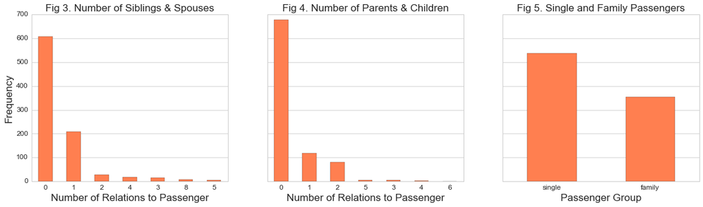

```python
def categorize_family(famMem):
    if famMem > 0:
        return "family"
    else:
        return "single"

#Add column to data frame
data['SingFam'] = data['SibSp'] + data['Parch']
data['SingFam'] = data['SingFam'].map(categorize_family)


#Create plots with the original SibSp and Parch data and SingFam column
fig, axs = plt.subplots(ncols=3, sharey=True, figsize=(20,5))

data['SibSp'].value_counts().plot(kind='bar',
    title='Fig 3. Number of Siblings & Spouses',ax=axs[0], color='coral')
data['Parch'].value_counts().plot(kind='bar',
    title='Fig 4. Number of Parents & Children',ax=axs[1], color='coral')
data['SingFam'].value_counts().plot(kind='bar',
    title='Fig 5. Single and Family Passengers',ax=axs[2], color='coral')
axs[0].set(xlabel='Number of Relations to Passenger',ylabel='Frequency')
axs[1].set(xlabel='Number of Relations to Passenger')
axs[2].set(xlabel='Passenger Group');

for i in range(3):
    axs[i].xaxis.grid(linewidth=0)
    axs[i].set_xticklabels(axs[i].xaxis.get_majorticklabels(), rotation=0)
```

Note: Each of the above graphs share the same y-axis

The original SibSp and Parch columns show a far larger greater divide between 0 relations and some relations, but the new category shows that there is some significant overlap where a passenger may have 0 in one of the categories, but a value greater than zero in the other.

#### Cabin Columns - 'CabLet' and 'CabNum'

The Cabin column is difficult to process, as the data does not follow a specific format for all available values. Most are given with a letter and then a 2 or 3 digit number, but some have multiple cabin values, and some have letters without numbers.

```python
print('The Cabin column has {d} unique values'.format\
      (d=len(data['Cabin'].value_counts())))
```

```
The Cabin column has 147 unique values
```

The first character in each object will represent the group, except in a few cases where there are entries with a single letter preceding an actual cabin value:

```python
data[data['Cabin'].str[1] == ' ']['Cabin']
```

```
75     F G73
128    F E69
699    F G63
715    F G73
Name: Cabin, dtype: object
```

In the above cases, the first 'F' is ignored. There are also several entries where there are multiple cabins written in:

```python
data[data['Cabin'].str[3] == ' ']['Cabin']
```

```
27         C23 C25 C27
88         C23 C25 C27
97             D10 D12
118            B58 B60
297            C22 C26
299            B58 B60
305            C22 C26
311    B57 B59 B63 B66
341        C23 C25 C27
390            B96 B98
435            B96 B98
438        C23 C25 C27
498            C22 C26
679        B51 B53 B55
700            C62 C64
742    B57 B59 B63 B66
763            B96 B98
789            B82 B84
802            B96 B98
872        B51 B53 B55
Name: Cabin, dtype: object
```

Luckily, all of these entries have two digit Cabin locations (which made it easier to search for as the 4th character would always be a space). For the purpose of this analysis the first cabin written in will be considered as the location.

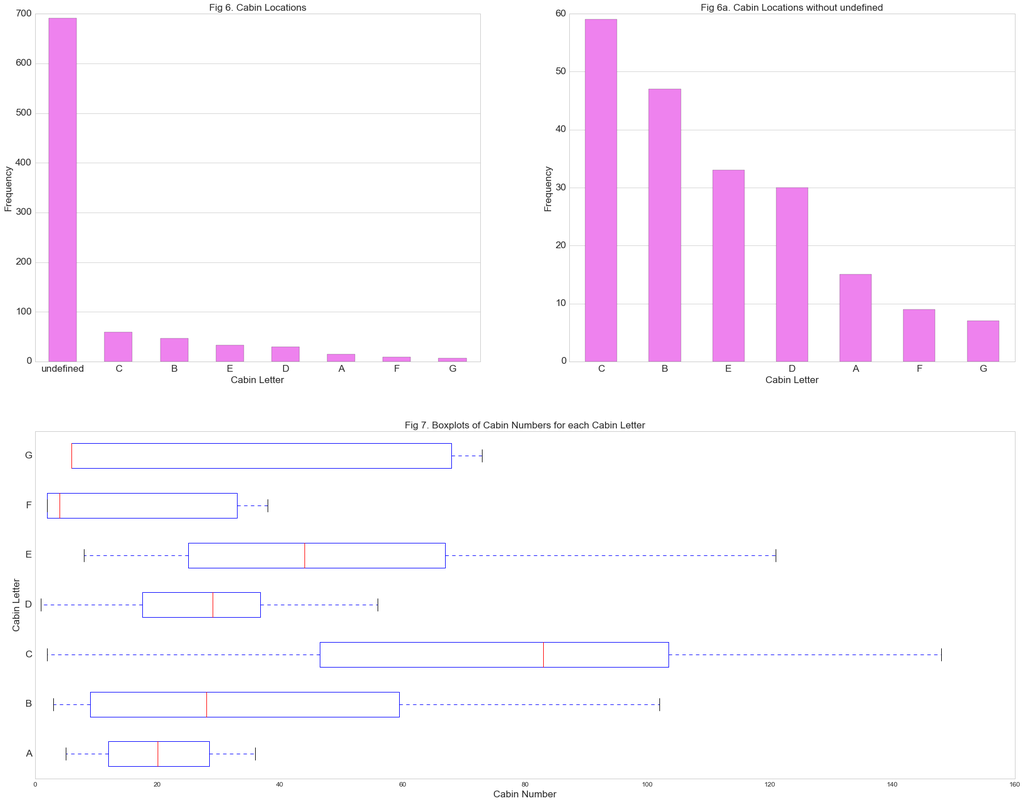

```python
def categorize_letter(text):
    #Make both NaN and single character entries undefined
    if pd.isnull(text) or len(text) == 1:
        return 'undefined'
    else:
        #Entries with a single character prefacing an actual cabin value
        if text[1] == ' ':
            return text[2]
        else:
            try:
                #All other entries should have the Cabin Letter as the first
                return text[0]
            except:
                #Error handling
                return 'error'

def categorize_number(text):
    if pd.isnull(text) or len(text) == 1:
        return -1
    else:
        #Entries with a single character prefacing an actual cabin value
        if text[1] == ' ':
            #Takes the numbers following the second entry
            return text[3:]
        #Entries with multiple Cabin values
        elif len(text) > 3 and text[3] == ' ':
            #Takes the first Cabin's numbers (No 3 digit Cabins possible)
            return text[1:2]
        #Entries with only one Cabin value
        elif ' ' not in text:
            return text[1:]
        else:
            #Error Handling
            return -2

#Entering the two series into the dataframe
data['CabLet'] = data['Cabin'].map(categorize_letter)
data['CabNum'] = pd.to_numeric(data['Cabin'].map(categorize_number))

#Print bar graphs with and without undefined,
#and a boxplot with the Cabin Numbers in each Group
fig, axs = plt.subplots(ncols=2, nrows=2, figsize=(30,25))
axs[1][0] = plt.subplot2grid((2,2),(1,0),colspan=2)
data['CabLet'].value_counts().plot(kind='bar',
    title='Fig 6. Cabin Locations',color='violet', ax=axs[0][0], fontsize='xx-large')
axs[0][0].set(ylabel='Frequency', xlabel='Cabin Letter')
data[data['CabLet']!='undefined']['CabLet'].value_counts().plot(kind='bar',
    title='Fig 6a. Cabin Locations without undefined',color='violet', ax=axs[0][1],
    fontsize='xx-large')
axs[0][1].set(ylabel = 'Frequency', xlabel='Cabin Letter')
data[data['CabNum']>0].boxplot('CabNum','CabLet',
    vert=False, grid=False, ax=axs[1][0], fontsize='xx-large')
axs[1][0].set(ylabel = 'Cabin Letter',xlabel='Cabin Number',
              title='Fig 7. Boxplots of Cabin Numbers for each Cabin Letter')
fig.suptitle(' ');
for i in range(2):
    axs[0][i].xaxis.grid(linewidth=0)
    axs[0][i].set_xticklabels(axs[0][i].xaxis.get_majorticklabels(), rotation=0)
```

## Survival Charts by Demographics

Survival statistics can now be created with our new categories. Using the questions posed in the introduction, the following cross tabulations are made:

- Male and Female survival
- Family and Single survival
- Children and Adult survival
- Passenger Class based survival
- Embarkment Location survival
- Cabin Letter survival

These crosstabs can be displayed as stackable bar charts that show the survivors and non-survivors in each category:

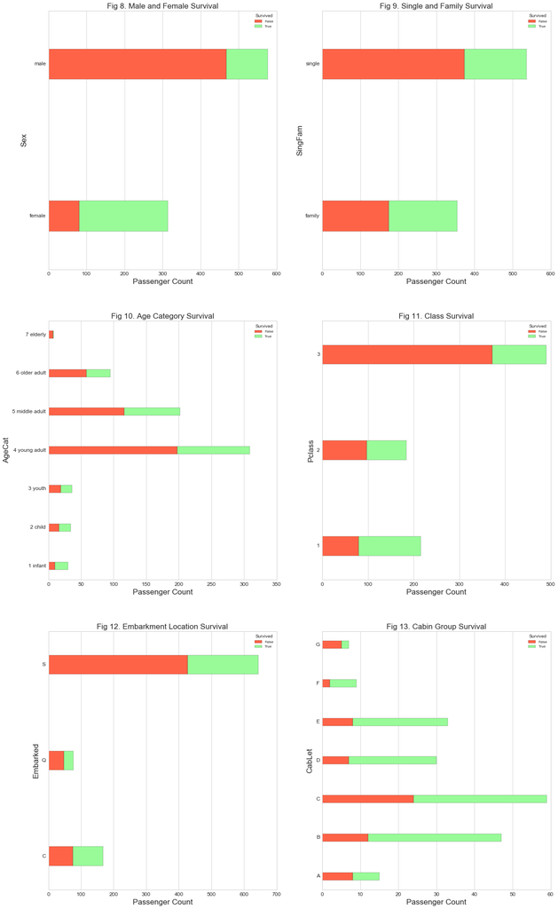

```python
#Survived column
srvd_cross = data['Survived'].astype(bool)

#Crosstab between Sex and Survival
M_F_cross = pd.crosstab(data['Sex'],srvd_cross)

#Crosstab between Family Status and Survival
Fam_Sing_cross = pd.crosstab(data['SingFam'],srvd_cross)

#Crosstab among Age groups (except for undefined ages) and Survival
Age_cross =\
 pd.crosstab(data[data['AgeCat']!='0 undefined']['AgeCat'],srvd_cross)

#Crosstab among Passenger Classes and Survival
Pclass_cross = pd.crosstab(data['Pclass'],srvd_cross)

#Crosstab among Embarkment locations and Survival
Embark_cross = pd.crosstab(data['Embarked'],srvd_cross)

#Crosstab among Cabin Groups (except for undefined groups) and Survival
CabLet_cross =\
 pd.crosstab(data[data['CabLet']!='undefined']['CabLet'],srvd_cross)

#Create plots as stacked bar charts
fig, axs = plt.subplots(nrows=3,ncols=2,figsize=(20,35))
M_F_cross.plot(kind='barh',width=.2,stacked=True,color=['tomato','palegreen'],
    ax=axs[0,0], title='Fig 8. Male and Female Survival')

Fam_Sing_cross.plot(kind='barh',width=.2,stacked=True,
    color=['tomato','palegreen'],ax=axs[0,1],title='Fig 9. Single and Family Survival')

Age_cross.plot(kind='barh',width=.2,stacked=True,color=['tomato','palegreen'],
    ax=axs[1,0],title='Fig 10. Age Category Survival')

Pclass_cross.plot(kind='barh',width=.2,stacked=True,color=['tomato','palegreen'],
    ax=axs[1,1], title='Fig 11. Class Survival')

Embark_cross.plot(kind='barh',width=.2,stacked=True,color=['tomato','palegreen'],
    ax=axs[2,0], title='Fig 12. Embarkment Location Survival')

CabLet_cross.plot(kind='barh',width=.2,stacked=True,color=['tomato','palegreen'],
    ax=axs[2,1], title='Fig 13. Cabin Group Survival');

for i in range(3):
    for j in range(2):
        axs[i][j].yaxis.grid(linewidth=0)
        axs[i][j].set(xlabel='Passenger Count')
```

Since Fare prices and Cabin Location are numerical values, these data series can be represented as box plots. For the box plot categories (Cabin Group and Passenger Class), the data will need to be split between survivors and non-survivors so that the surviving and non-surviving box plots can be paired for visual interpretations:

```python
data['CabLet_S'] = data['CabLet']+'-'+data['Survived'].map(str)
data['Class_S']  = data['Pclass'].map(str)+'-'+data['Survived'].map(str)
```

Now that there are columns that discerns between survivors and non-survivors, the following relationships will be shown:

- Plot 1: Box plot with Cabin Number vs Cabin Letter-Survivorship
- Plot 2: Box plot with Fare vs Cabin Letter-Survivorship
- Plot 3: Box plot with Fare vs Passenger Class-Survivorship

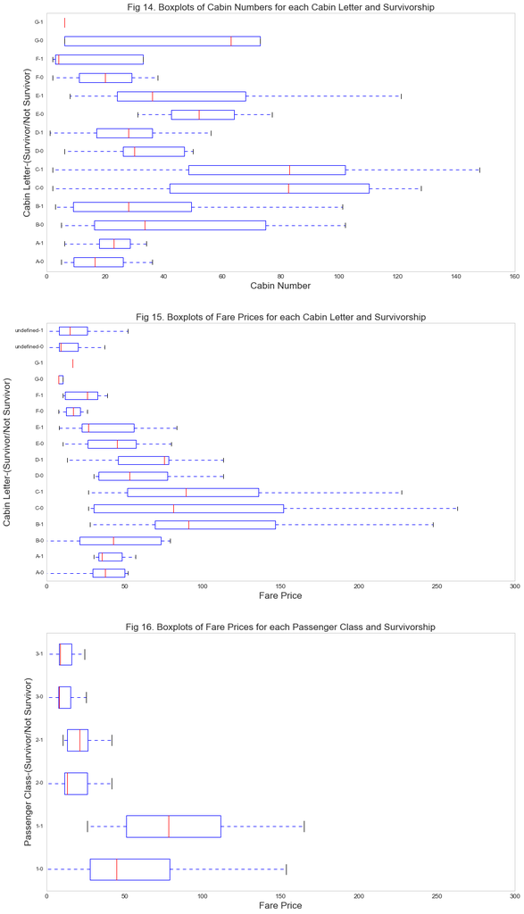

```python
# Dataframe with just The real Cabin Numbers (excludes undefined)
# and the Cabin Letter-Survival
# No need to filter out undefined groups in Cabin Letter since
# all of the real Cabin Numbers have an associated group

Loc_CabLet_S = data[data['CabNum']>0][['CabNum','CabLet_S']]

#Dataframe with just the Fare price and the Cabin Letter-Survival
#(except for undefined groups)
Fare_CabLet_S =\
 data[(data['CabLet_S']!='undefined')][['CabLet_S','Fare']]
#Dataframe with just the Fare price and the Passenger Class
Fare_Pclass_S = data[['Class_S','Fare']]

#Creates the three box plots
fig, axs = plt.subplots(nrows=3, figsize=(15,30))
Loc_CabLet_S.boxplot('CabNum','CabLet_S', vert=False,ax=axs[0], grid=False)
axs[0].set(ylabel = 'Cabin Letter-(Survivor/Not Survivor)',xlabel='Cabin Number',
              title='Fig 14. Boxplots of Cabin Numbers for each Cabin Letter and Survivorship')
Fare_CabLet_S.boxplot('Fare','CabLet_S', vert=False,ax=axs[1], grid=False)
axs[1].set(ylabel = 'Cabin Letter-(Survivor/Not Survivor)',xlabel='Fare Price',
              title='Fig 15. Boxplots of Fare Prices for each Cabin Letter and Survivorship')
axs[1].set_xlim([0,300])
Fare_Pclass_S.boxplot('Fare','Class_S', vert=False,ax=axs[2], grid=False)
axs[2].set(ylabel = 'Passenger Class-(Survivor/Not Survivor)',xlabel='Fare Price',
              title='Fig 16. Boxplots of Fare Prices for each Passenger Class and Survivorship')
axs[2].set_xlim([0,300])
fig.suptitle(' ');
```

## Visual interpretations

From the questions posed in the introduction:

- **Were women more likely to survive than men?**

  It does seem that women were significantly more likely to survive than men.
- **Were families more likely to survive than single passengers?**

  It looks like half of the passengers with families survived, while only a third of single passengers did the same.
- **Were children more likely to survive than adults?**

  Although it's difficult to tell with each of the categories under different scales, it looks like infants were more likely to survive than the other categories, but children and youth seemed to be no different than young and middle adults. The older adults and elderly look like they were more likely to not survive.
- **Were first class passengers more likely to survive than second or third?**

  First class passengers were more likely to survive than Second and Third. Second class passengers were also more likely to survive than Third.
- **Were passengers from certain Embarkment locations more likely to survive?**

  Visually, it doesn't look like any particular group is an outlier, or if there is a trend among the groups.
- **Were passengers from lower numerical Cabin locations more likely to survive?**

  It appears for most Cabin groups, the survivors were slightly more likely to have lower numerical values
- **Were passengers with higher fares in each Cabin group more likely to survive?**

  For Cabin group B only there appears to be a large difference in fares paid between survivors and non-survivors.
- **Were passengers with higher fares in each passenger Class more likely to survive?**

  For First class passengers it looks like survivors had a higher fare than non-survivors, but no discernible difference between survivors' and non-survivors' fares for Second and Third class passengers.

With these insights, a few more questions can be posed for further analysis:

- Were men with families more likely to survive than single men?
- Were women traveling alone less likely to survive than those with family on board?
- Did lower numerical locations correlate to higher or lower fares?
- Were certain embarkment locations correlated to certain passenger classes?

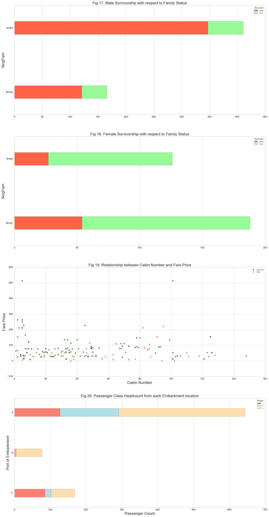

```python
#Crosstabs of each Gender between Family status and Survival
M_Fam_Sing_cross =\
 pd.crosstab(data[data['Sex']=='male']['SingFam'],srvd_cross)
F_Fam_Sing_cross =\
 pd.crosstab(data[data['Sex']=='female']['SingFam'],srvd_cross)

#Dataframes of real Cabin numbers and Fares into two groups:
#survivors and nonsurvivors

#The two dataframes allow the scatterplot below to have different
#colors for survivors and nonsurvivors
Surv_Fare_Loc =\
 data[(data['CabNum']>0)&(data['Survived']==1)][['CabNum','Fare']]
NSurv_Fare_Loc =\
 data[(data['CabNum']>0)&(data['Survived']==0)][['CabNum','Fare']]
#Crosstab between Embarkment location and Passenger Class
Embark_Pclass_cross = pd.crosstab(data['Embarked'],data['Pclass'])

#Builds plots
fig, axs = plt.subplots(nrows=4, figsize=(20,40))
M_Fam_Sing_cross.plot(kind='barh',width=.2,stacked=True,color=['tomato','palegreen'],
    ax=axs[0], title='Fig 17. Male Survivorship with respect to Family Status')
F_Fam_Sing_cross.plot(kind='barh',width=.2,stacked=True,color=['tomato','palegreen'],
    ax=axs[1],title='Fig 18. Female Survivorship with respect to Family Status')
Surv_Fare_Loc.plot(kind='scatter', x='CabNum',y='Fare', ax=axs[2],
                   color='darkgreen', label='Survived')
NSurv_Fare_Loc.plot(kind='scatter', x='CabNum',y='Fare', ax=axs[2],
                    color='tomato', label='Died')
axs[2].set(ylabel = 'Fare Price',xlabel='Cabin Number',
              title='Fig 19. Relationship between Cabin Number and Fare Price')
axs[2].set_xlim([0,160])
Embark_Pclass_cross.plot(kind='barh',width=.2,stacked=True,ax=axs[3],
               title='Fig 20. Passenger Class Headcount from each Embarkment location',
                         color=['salmon','powderblue','navajowhite'])
axs[3].set(ylabel = 'Port of Embarkment',xlabel='Passenger Count',)
for i in range(4):
    if i != 2:
        axs[i].yaxis.grid(linewidth=0)

fig.suptitle(' ');
```

In the above figures:

## Statistical Inference

To keep visual interpretations from being misleading, there are 3 tests that can verify the analysis:

- The Chi Square test can be used for comparing two sets of categorical data (All of the bar charts)
- The T-test can be used for comparing numerical data of two categories (All of the box plots)
- The Linear Regression test can be used to find trends between two sets of numerical data (The scatter plot)

```python
#Chi Square test
def chi2test(question, desc1, desc2, crosstab):

    #Performs Chi Square on the crosstab data
    chi2, pval, df, expval = chi2_contingency(crosstab)

    #Accepts or rejects the null hypothesis of
    #independence between categories
    if pval < 0.05:
        ans=('REJECTED with a 95% confidence level',
             'dependent')
    else:
        ans=('NOT REJECTED with a 95% confidence level',
             'independent')


    str1 = 'Cross-tabulation between {d1} and {d2}:'.format\
            (d1=desc1,d2=desc2)
    #Show the table of the initial data
    table1 = crosstab
    str2 = 'Expected values from the chi-square test:'
    #Show the table of the expected values
    table2 = pd.DataFrame(np.around(expval, decimals=1),
                    columns=list(crosstab.columns.values),
                    index=list(crosstab.index.values))
    #Show the test statistics
    str3 = '\nchi-square statistic = {c2:.3f} \
            \n  degrees of freedom = {deg} \
            \n             p-value = {pv:.3E} \
            \n     null hypothesis = {hyp} \
            \n\n##### Relationship between {d1} and {d2} is likely to be {hyp2} \
            \n'.format(c2=chi2,deg=df,pv=pval,d1=desc1,
             d2=desc2,hyp=ans[0],hyp2=ans[1])

    #Print report
    display(Markdown('### '+question))
    display(Markdown('\n###### '+str1))
    display(table1)
    display(Markdown('\n###### '+str2))
    display(table2)
    display(Markdown(str3))
    display(Markdown('---'))

    return

#T-test for difference in mean
def ttest(question, cat1, cat2, df):
    #Build a summary table to show all of the comparisons
    collabel = ['n0','n1','x0','x1','s0','s1','T-stat',
                'p-value','null hyp']
    rowlabel = df[cat1].unique().tolist()
    rowlabel.sort()

    #Initializes an array of zeros with the
    #right number of cells to fit the table
    vals = np.zeros((len(rowlabel),len(collabel)))

    #Writes descriptive statistics into table for each
    #comparison between surviving and non-surviving passengers
    for i, s in enumerate(rowlabel):
        vals[i,0] = df[(df[cat1]==s)&(df['Survived']==0)][cat2].count()
        vals[i,1] = df[(df[cat1]==s)&(df['Survived']==1)][cat2].count()
        vals[i,2] = df[(df[cat1]==s)&(df['Survived']==0)][cat2].mean()
        vals[i,3] = df[(df[cat1]==s)&(df['Survived']==1)][cat2].mean()
        vals[i,4] = df[(df[cat1]==s)&(df['Survived']==0)][cat2].std()
        vals[i,5] = df[(df[cat1]==s)&(df['Survived']==1)][cat2].std()
        #Runs the t-test to return the test staistic and the p value
        t = ttest_ind_from_stats(vals[i,2],vals[i,4],vals[i,0],
                                 vals[i,3],vals[i,5],vals[i,1],
                                 equal_var=False)

        #Writes the final statistical values into the table
        vals[i,6] = t[0]
        vals[i,7] = t[1]
        #A two-tailed t-test is assumed since the difference in the
        #means is being tested in either direction
        if t[1] < 0.025:
            ans = 1
            #Since this NumPy array can only hold numerical values,
            #1 will represent a rejection of the null.
        else:
            ans = 0 #0 represents that the null cannot be rejected
        vals[i,8] = ans
    #Builds the Pandas table of the T-tests in each category
    vals = np.around(vals,decimals=3)
    table = pd.DataFrame(vals,columns=collabel,index=rowlabel)

    #Prints report
    display(Markdown('### '+question))
    display(Markdown('A value of 1.0 under null hyp indicates that the null\
    \nhypothesis was rejected under a 95% confidence level'))
    display(table)
    display(Markdown('---'))
    return


#Linear regression test
def linreg(question, cat1, cat2, df):
        #Runs the linear regression test
        lr = linregress(df[cat1].tolist(),df[cat2].tolist())
        #Builds report with the test statistics
        str1 = '\n    slope = {slp:.3f}\
                \nintercept = {cpt:.3f}\
                \nr-squared = {rvl:.3f}\
                \n  p-value = {pvl:.3E}\
                \n  std err = {ser:.3f}\
                '.format(slp=lr[0],cpt=lr[1],rvl=lr[2]**2,
                         pvl=lr[3],ser=lr[4])
        #Accepts/rejects the null hypothesis under a 95% confidence level
        if lr[3] < 0.05:
            ans = 'some significant correlation between {cat1}\
            and {cat2}'.format(cat1=cat1,cat2=cat2)
        else:
            ans = 'no significant correlation between {cat1} \
            and {cat2}'.format(cat1=cat1,cat2=cat2)
        str2 = '\n\n##### With a p-value of {pvl:.3E}, there is\
        {ans} under a 95% confidence level.'.format(pvl=lr[3],ans=ans)
        #Prints Report
        display(Markdown('### '+question))
        display(Markdown(str1))
        display(Markdown(str2))
        display(Markdown('---'))
        return
```

```python
#Creates a list of the test inputs
testList = (#These may be cut off in the pdf output
 ('Question 1: Relationship between Male and Female Survivorship',
 'Gender','Survival',M_F_cross),
 ('Question 2: Relationship between Family and Single Survivorship',
  'Family Status','Survival',Fam_Sing_cross),
 ('Question 3: Relationship among Age Category Survivorship',
  'Age Categories','Survival',Age_cross),
 ('Question 4: Relationship among Passenger Class Survivorship',
  'Passenger Class','Survival',Pclass_cross),
 ('Question 5: Relationship among Embarkment Location Survivorship',
  'Embarkment Location', 'Survival', Embark_cross),
 ('Question 6: Relationship among Cabin Group Survivorship',
  'Cabin Group','Survival',CabLet_cross),
 ('Question 7: Relationship between Cabin Group and Number on Survivorship',
  'CabLet','CabNum',data),
 ('Question 8: Relationship between Cabin Group and Fare Price on Survivorship',
  'CabLet','Fare',data),
 ('Question 9: Relationship between Passenger Class and Fare Price on Survivorship',
  'Pclass','Fare',data),
 ('Question 10: Relationship between Family and Single Survivorship\
   controlling for Male Passengers',
  'Males in Families','Single Males',M_Fam_Sing_cross),
 ('Question 11: Relationship between Family and Single Survivorship\
   controlling for Female Passengers',
  'Females in Families','Single',F_Fam_Sing_cross),
 ('Question 12: Correlation between Cabin Number and Fare Price',
  'CabNum','Fare', data[(data['CabNum']>0)][['CabNum','Fare']]),
 ('Question 13: Relationship between Embarkment locations and Passenger Classes',
  'Embarkment','Passenger Classes',Embark_Pclass_cross))

#The test to run for each Question
testList2=('Chi2','Chi2','Chi2','Chi2','Chi2','Chi2',
           'Ttest','Ttest','Ttest','Chi2','Chi2','Linreg','Chi2')

#Cycles through testList2 to find the test to perform,
#and then performs the test on the corresponding list in testList1
for i,s in enumerate(testList2):
    if s == 'Chi2':
        chi2test(testList[i][0],testList[i][1],
                 testList[i][2],testList[i][3])
    elif s == 'Ttest':
        ttest(testList[i][0],testList[i][1],
              testList[i][2],testList[i][3])
    elif s == 'Linreg':
        linreg(testList[i][0],testList[i][1],
               testList[i][2],testList[i][3])
    else:
        print('Error on Question {i}'.format(i=i))
```

Question 1: Relationship between Male and Female Survivorship

Cross-tabulation between Gender and Survival:

| Survived Sex | False | True |
| --- | --- | --- |
| female | 81 | 233 |
| male | 468 | 109 |

Expected values from the chi-square test:

|  | False | True |
| --- | --- | --- |
| female | 193.5 | 120.5 |
| male | 355.5 | 221.5 |

chi-square statistic = 260.717  
degrees of freedom = 1  
p-value = 1.197E-58  
null hypothesis = REJECTED with a 95% confidence level

Relationship between Gender and Survival is likely to be dependent

Question 2: Relationship between Family and Single Survivorship

Cross-tabulation between Family Status and Survival:

| Survived SingFam | False | True |
| --- | --- | --- |
| family | 175 | 179 |
| single | 374 | 163 |

Expected values from the chi-square test:

|  | False | True |
| --- | --- | --- |
| family | 218.1 | 135.9 |
| single | 330.9 | 206.1 |

chi-square statistic = 36.001  
degrees of freedom = 1  
p-value = 1.973E-09  
null hypothesis = REJECTED with a 95% confidence level

Relationship between Family Status and Survival is likely to be dependent

Question 3: Relationship among Age Category Survivorship

Cross-tabulation between Age Categories and Survival:

| Survived AgeCat | False | True |
| --- | --- | --- |
| 1 infant | 10 | 20 |
| 2 child | 16 | 18 |
| 3 youth | 19 | 17 |
| 4 young adult | 198 | 111 |
| 5 middle adult | 116 | 86 |
| 6 older adult | 58 | 37 |
| 7 elderly | 7 | 1 |

Expected values from the chi-square test:

|  | False | True |
| --- | --- | --- |
| 1 infant | 17.8 | 12.2 |
| 2 child | 20.2 | 13.8 |
| 3 youth | 21.4 | 14.6 |
| 4 young adult | 183.5 | 125.5 |
| 5 middle adult | 120.0 | 82.0 |
| 6 older adult | 56.4 | 38.6 |
| 7 elderly | 4.8 | 3.2 |

chi-square statistic = 17.109  
degrees of freedom = 6  
p-value = 8.891E-03  
null hypothesis = REJECTED with a 95% confidence level

Relationship between Age Categories and Survival is likely to be dependent

Question 4: Relationship among Passenger Class Survivorship

Cross-tabulation between Passenger Class and Survival:

| Survived Pclass | False | True |
| --- | --- | --- |
| 1 | 80 | 136 |
| 2 | 97 | 87 |
| 3 | 372 | 119 |

Expected values from the chi-square test:

|  | False | True |
| --- | --- | --- |
| 1 | 133.1 | 82.9 |
| 2 | 113.4 | 70.6 |
| 3 | 302.5 | 188.5 |

chi-square statistic = 102.889  
degrees of freedom = 2  
p-value = 4.549E-23  
null hypothesis = REJECTED with a 95% confidence level

Relationship between Passenger Class and Survival is likely to be dependent

Question 5: Relationship among Embarkment Location Survivorship

Cross-tabulation between Embarkment Location and Survival:

| Survived Embarked | False | True |
| --- | --- | --- |
| C | 75 | 93 |
| Q | 47 | 30 |
| S | 427 | 217 |

Expected values from the chi-square test:

|  | False | True |
| --- | --- | --- |
| C | 103.7 | 64.3 |
| Q | 47.6 | 29.4 |
| S | 397.7 | 246.3 |

chi-square statistic = 26.489  
degrees of freedom = 2  
p-value = 1.770E-06  
null hypothesis = REJECTED with a 95% confidence level

Relationship between Embarkment Location and Survival is likely to be dependent

Question 6: Relationship among Cabin Group Survivorship

Cross-tabulation between Cabin Group and Survival:

| Survived CabLet | False | True |
| --- | --- | --- |
| A | 8 | 7 |
| B | 12 | 35 |
| C | 24 | 35 |
| D | 7 | 23 |
| E | 8 | 25 |
| F | 2 | 7 |
| G | 5 | 2 |

Expected values from the chi-square test:

|  | False | True |
| --- | --- | --- |
| A | 5.0 | 10.0 |
| B | 15.5 | 31.5 |
| C | 19.5 | 39.5 |
| D | 9.9 | 20.1 |
| E | 10.9 | 22.1 |
| F | 3.0 | 6.0 |
| G | 2.3 | 4.7 |

chi-square statistic = 13.124  
degrees of freedom = 6  
p-value = 4.110E-02  
null hypothesis = REJECTED with a 95% confidence level

Relationship between Cabin Group and Survival is likely to be dependent

Question 7: Relationship between Cabin Group and Number on Survivorship

A value of 1.0 under null hyp indicates that the null  
hypothesis was rejected under a 95% confidence level

|  | n0 | n1 | x0 | x1 | s0 | s1 | T-stat | p-value | null hyp |
| --- | --- | --- | --- | --- | --- | --- | --- | --- | --- |
| A | 8.0 | 7.0 | 18.375 | 22.286 | 11.501 | 9.464 | -0.722 | 0.483 | 0.0 |
| B | 12.0 | 35.0 | 43.083 | 34.314 | 35.771 | 28.891 | 0.768 | 0.454 | 0.0 |
| C | 24.0 | 35.0 | 71.167 | 72.800 | 44.385 | 41.889 | -0.142 | 0.888 | 0.0 |
| D | 7.0 | 23.0 | 33.143 | 27.261 | 15.910 | 14.629 | 0.872 | 0.405 | 0.0 |
| E | 8.0 | 25.0 | 53.000 | 48.840 | 15.748 | 35.505 | 0.461 | 0.648 | 0.0 |
| F | 2.0 | 7.0 | 20.000 | 15.857 | 25.456 | 16.056 | 0.218 | 0.858 | 0.0 |
| G | 5.0 | 2.0 | 44.200 | 6.000 | 35.110 | 0.000 | 2.433 | 0.072 | 0.0 |
| undefined | 483.0 | 208.0 | -1.000 | -1.000 | 0.000 | 0.000 | NaN | NaN | 0.0 |

Question 8: Relationship between Cabin Group and Fare Price on Survivorship

A value of 1.0 under null hyp indicates that the null  
hypothesis was rejected under a 95% confidence level

|  | n0 | n1 | x0 | x1 | s0 | s1 | T-stat | p-value | null hyp |
| --- | --- | --- | --- | --- | --- | --- | --- | --- | --- |
| A | 8.0 | 7.0 | 35.496 | 44.341 | 17.333 | 18.835 | -0.942 | 0.364 | 0.0 |
| B | 12.0 | 35.0 | 57.138 | 132.832 | 66.713 | 114.968 | -2.767 | 0.009 | 1.0 |
| C | 24.0 | 35.0 | 99.972 | 100.274 | 76.742 | 66.549 | -0.016 | 0.988 | 0.0 |
| D | 7.0 | 23.0 | 59.613 | 62.266 | 31.154 | 26.770 | -0.204 | 0.843 | 0.0 |
| E | 8.0 | 25.0 | 43.716 | 45.820 | 22.566 | 35.305 | -0.197 | 0.846 | 0.0 |
| F | 2.0 | 7.0 | 16.875 | 23.429 | 12.905 | 12.525 | -0.638 | 0.603 | 0.0 |
| G | 5.0 | 2.0 | 8.775 | 16.700 | 1.540 | 0.000 | -11.504 | 0.000 | 1.0 |
| undefined | 483.0 | 208.0 | 16.416 | 25.515 | 17.757 | 43.957 | -2.886 | 0.004 | 1.0 |

Question 9: Relationship between Passenger Class and Fare Price on Survivorship

A value of 1.0 under null hyp indicates that the null  
hypothesis was rejected under a 95% confidence level

|  | n0 | n1 | x0 | x1 | s0 | s1 | T-stat | p-value | null hyp |
| --- | --- | --- | --- | --- | --- | --- | --- | --- | --- |
| 1 | 80.0 | 136.0 | 64.684 | 95.608 | 60.662 | 85.287 | -3.100 | 0.002 | 1.0 |
| 2 | 97.0 | 87.0 | 19.412 | 22.056 | 15.307 | 10.854 | -1.361 | 0.175 | 0.0 |
| 3 | 372.0 | 119.0 | 13.669 | 13.695 | 12.118 | 10.693 | -0.022 | 0.983 | 0.0 |

Question 10: Relationship between Family and Single Survivorship controlling for Male Passengers

Cross-tabulation between Males in Families and Single Males:

| Survived SingFam | False | True |
| --- | --- | --- |
| family | 121 | 45 |
| single | 347 | 64 |

Expected values from the chi-square test:

|  | False | True |
| --- | --- | --- |
| family | 134.6 | 31.4 |
| single | 333.4 | 77.6 |

chi-square statistic = 9.532  
degrees of freedom = 1  
p-value = 2.019E-03  
null hypothesis = REJECTED with a 95% confidence level

Relationship between Males in Families and Single Males is likely to be dependent

Question 11: Relationship between Family and Single Survivorship controlling for Female Passengers

Cross-tabulation between Females in Families and Single:

| Survived SingFam | False | True |
| --- | --- | --- |
| family | 54 | 134 |
| single | 27 | 99 |

Expected values from the chi-square test:

|  | False | True |
| --- | --- | --- |
| family | 48.5 | 139.5 |
| single | 32.5 | 93.5 |

chi-square statistic = 1.733  
degrees of freedom = 1  
p-value = 1.880E-01  
null hypothesis = NOT REJECTED with a 95% confidence level

Relationship between Females in Families and Single is likely to be independent

Question 12: Correlation between Cabin Number and Fare Price

```
slope = -0.258
```

intercept = 89.117  
r-squared = 0.016  
p-value = 7.224E-02  
std err = 0.143

With a p-value of 7.224E-02, there is no significant correlation between CabNum and Fare under a 95% confidence level.

Question 13: Relationship between Embarkment locations and Passenger Classes

Cross-tabulation between Embarkment and Passenger Classes:

| Pclass Embarked | 1 | 2 | 3 |
| --- | --- | --- | --- |
| C | 85 | 17 | 66 |
| Q | 2 | 3 | 72 |
| S | 127 | 164 | 353 |

Expected values from the chi-square test:

|  | 1 | 2 | 3 |
| --- | --- | --- | --- |
| C | 40.4 | 34.8 | 92.8 |
| Q | 18.5 | 15.9 | 42.5 |
| S | 155.0 | 133.3 | 355.7 |

chi-square statistic = 123.752  
degrees of freedom = 4  
p-value = 8.435E-26  
null hypothesis = REJECTED with a 95% confidence level

Relationship between Embarkment and Passenger Classes is likely to be dependent

## Conclusions and Limitations

#### From Chi Square testing

Comparing the actual value vs the expected value, along with the p-value:

- Women were overwhelmingly more likely to survive than men.
- Families were more likely to survive than single passengers.
- Younger age categories were more likely to survive than older categories.
- First class passengers were more likely to survive than second, and second more likely than third.
- Passengers from the 'C' embarkment location were more likely to survive, and 'S' less likely to survive.
- Passengers from 'B', 'D', and 'E' Cabin groups were more likely to survive than expected, but the null hypothesis would not have been rejected with a confidence level higher than 95% with a p-value of .0411. So while survival is dependent on Cabin Groups, it's not as dependent as it is on other parameters.
- Men with family members on board were more likely to survive than men without family. This might be because males with families skew slightly younger than single males, which could cause some correlation to survival since younger passengers were more likely to survive:

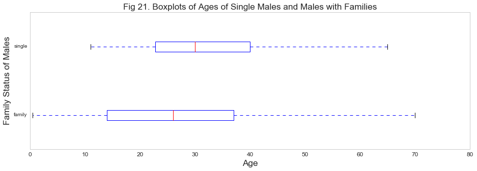

```python
fig, axs = plt.subplots(figsize=(15,5))
data[(data['Sex']=='male')&(pd.notnull(data['Age']))]\
[['SingFam','Age']].boxplot('Age','SingFam', vert=False, ax=axs, grid=False)
axs.set_xlabel('Age')
axs.set_ylabel('Family Status of Males')
axs.set(ylabel = 'Family Status of Males',xlabel='Age',
              title='Fig 21. Boxplots of Ages of Single Males and Males with Families')
fig.suptitle(' ');
```

- Women with family members on board were no more likely to survive than Women without family. This contrasts the male counterpart above most likely because female passengers were more likely to survive in general regardless of other demographics.
- Passengers from the 'C' embarkment location were more likely to have first class passengers than expected, which is probably why passengers from 'C' were more likely to survive than passengers from other embarkment locations.

#### From T-testing between two sample means

- There was no statistical difference between Cabin Number of survivors and non-survivors among any of the Cabin Groups.
- Within Cabin Group 'B' and 'G' only, there was a statistical difference between the fares paid by survivors and non-survivors. Survivors with undefined Cabins had also paid higher fares than non-survivors, but this is likely because without the Cabin groups defined, there are passengers from different classes all represented here (Higher fares for First Class passengers who were more likely to survive in general).
- Within First Class, survivors were statistically paying a higher fare than non-survivors, but no difference in fares for Second or Third Class.

#### From Linear Regression

- With an extremely low r-squared value and a p-value outside the 95% confidence interval, there does not seem to be a linear relationship between Cabin Number and Fare price

#### Limitations of Analysis

- The lack of age entries from all the data limits the understanding of its relationship to survivorship. A common assertion in popular media on passenger survival was that women and children were to go first, but survival was not as dependent on Age Categories than it was on Passenger Class. Since there were many missing entries on age, it's difficult to say conclusively that age was less important than passenger class.
- It is still difficult to draw any conclusions on survival based on location about all of the passengers since so many entries did not have a Cabin value present The location based questions could definitely have been more in depth if the dataset had more entries on Cabins. It may have also been helpful to have a dataset tying Cabins (or a group of Cabins) to a parameter showing the distance to the nearest lifeboat.

## References

- Kaggle Documentation:
  - https://www.kaggle.com/c/titanic/data
- Pandas Documentation:
  - http://pandas.pydata.org/pandas-docs/stable/api.html
- Scipy Testing:
  - http://docs.scipy.org/doc/scipy-0.15.1/reference/generated/scipy.stats.chi2_contingency.html
  - http://docs.scipy.org/doc/scipy-0.17.0/reference/generated/scipy.stats.ttest_ind_from_stats.html
  - http://docs.scipy.org/doc/scipy/reference/generated/scipy.stats.linregress.html
- Visualization (for a better understanding of plotting through pandas):
  - http://pandas.pydata.org/pandas-docs/stable/visualization.html
- Hiding warnings to keep document clean:
  - http://stackoverflow.com/questions/9031783/hide-all-warnings-in-ipython